# Locating Proto Oceanic

Pawley, A.

## 1. Introduction

This chapter briefly describes the major biogeographical regions of Oceania and Island Southeast Asia, summarises the evidence for locating the Proto Oceanic speech community in the Bismarck Archipelago, and refers to the range of environments and environmental features to be encountered there.[^1]

## 2. The major biogeographic regions of Oceania

Oceania is often divided into three main geographic regions: Melanesia, Polynesia and Micronesia. However, a more useful primary division for understanding the history of plants and animals, and, particularly, of humans in the Pacific is between Near Oceania and Remote Oceania.[^2]

Modern Near Oceania consists of Australia and that part of the Pacific Islands whose chief land masses are New Guinea, the Bismarck archipelago and the Solomons archipelago, extending as far east as Makira (formerly known as San Cristobal). Some of the islands in Near Oceania are formidable in their size and rugged terrain. New Guinea is 2300 km long and has a mountainous interior that extends the length of the island, with peaks reaching 4500 m. New Britain is 480 km long and from 50 to 80 km across, mountainous and actively volcanic. New Ireland is 350 km long though never more than 50 km across. Bougainville is more compact but has a landmass similar to New Ireland. The islands of Near Oceania for the most part form an intervisible series of landmasses which served as stepping-stones for the dispersion of plants, animals and people, enhanced at times by lower sea levels during the late Pleistocene.

The east-west boundary between Near and Remote Oceania is the ocean gap of 350 km separating the easternmost point of the Solomons chain from the small Santa Cruz group. Beyond the Solomons the landmasses are generally smaller and island groups are separated from each other by long distances of open sea. Along the equator and to its north lie several extensive groups of small islands traditionally grouped under the heading of Micronesia: the Marianas, the Carolines, the Marshalls and Kiribati. The large archipelagoes of Vanuatu and New Caledonia-Loyalties are southeast of the Solomons. Some 900 km east of Vanuatu are the Fiji group and Rotuma. The vast Polynesian Triangle, whose apices are Hawaii, New Zealand and Easter Island, contains some extremely isolated islands and island groups, several being separated by ocean gaps of between 1000 and 3000 kilometres from the nearest inhabited land.

The western landmasses of Near Oceania are close to the easternmost islands of the Indo-Malaysian archipelago. The latter consist of two biogeographical regions: Sundaland and Wallacea. At various times during the last Pleistocene glaciation, beginning about 120,000 years ago, sea levels were much lower than today, with an extreme lowpoint at about 18,000 years ago. For much of this period Sumatra, Java, Borneo and Palawan were connected to continental Southeast Asia by the Sunda shelf. This continental extension, Sundaland, was permanently separated by short ocean gaps from the region known as Wallacea, which includes the Philippines, Sulawesi, the Lesser Sundas and the Moluccas. Wallacea has always been a world of islands, whose flora and fauna are intermediate between the ‘Southeast Asian’ and the ‘Australian’ types. During the Upper Pleistocene and until about 8000 years ago New Guinea was linked to Australia, forming the continent known as Sahul. They share a distinctive mammalian and bird fauna and a number of distinctive plant genera. Map 5 shows the major biogeographic regions of island SE Asia and the Pacific.

Within Wallacea, stretches of open sea up to 60–70 km were traversed by the first settlers—very likely the first substantial open sea voyages made by humans. The shortest sea crossings from Wallacea to the Australia-New Guinea continent were between 65 and 100 km. These crossings were made no later than 40,000 BP, because human settlement of Australia and New Guinea is securely dated to that time, and there are earlier, less widely accepted dates, indicating that Australia may have been settled as early as 60,000 BP.

The relatively narrow (70 km) but permanent ocean gap between New Guinea and New Britain has proved an important barrier limiting the spread of plants and animals. New Guinea harbours far more species and genera than any other region of the Pacific. Almost all the plant genera of the Bismarcks (627 of 632) and Solomons (637 of 654) are shared with New Guinea (Mayr & Diamond 2001). However, 800 genera present in New Guinea are lacking in the Bismarcks and Solomons (Mayr and Diamond refer to the latter two archipelagoes as making up ‘Northern Melanesia’). New Guinea has about 520 species of land birds (and in any one locality there are likely to be at least 200 species), New Britain about 80, the Solomons 127, Fiji 54, Samoa 33, Tonga 20, the Society Islands 17 and the Marquesas 11. Whereas New Guinea has some 130 species of indigenous terrestrial mammal species (Flannery 1995), the Bismarcks have one bandicoot and one wallaby species, two phalanger species and four genera of rats, and the Solomons have one phalanger species and three genera of rats. (When it comes to mammals, it is only in bats that New Guinea and Northern Melanesia show a comparable diversity: New Guinea has about 70 bat species and the Bismarcks and Solomons about 58.) This diminution in land-dwelling biota must have greatly handicapped human colonists of Northern Melanesia dependent on hunting-and-gathering to get their food.

The divide between Near and Remote Oceania is also an important one for fauna and flora distribution. Roger Green (1991a: 495) notes that:

> all terrestrial mammals other than rats and mice or those which accompanied people reach their eastward limit in the Solomons. The same applies to all fresh-water mussels, and most of the Palaeo-Oriental land-snail fauna. Thirty Papuan and Malayan genera of birds find their eastern limits here, as do 162 genera of seed-plants, about 24% of the total.

Even in marine life the difference is marked. The reefs of the Bismarck and Solomons show a much richer diversty of fish, molluscs, echinoderms, crustacea, seaweeds, and other edible life than those of Remote Oceanic.

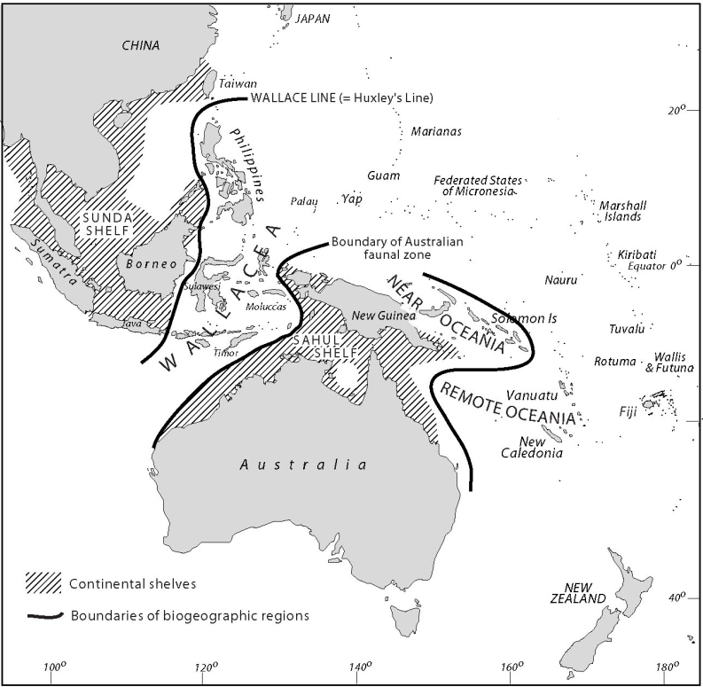

**Map 5:** Major biogeographic regions of Island SE Asia and the Pacific: Sundaland, Wallacea, Near Oceania and Remote Oceania

## 3. Early human settlement of Near Oceania

For human settlement of the Pacific the Near/Remote Oceania boundary proved to be far more formidable than the ocean gaps within Wallacea or Near Oceania.

The crossings from New Guinea to New Britain and from New Britain to New Ireland occurred no later than 35,000 years ago (Allen & Gosden 1996, Allen & White 1989, Gosden & Specht 1991, Pavlides & Gosden 1994). The Manus group was reached by at least 21,000 BP and probably a good deal earlier (Ambrose 2002). The earliest dates for Buka-Bougainville are about 28,000 BP (Spriggs 1997a). At that time most of today’s Solomon Islands were joined into a single landmass, and the first settlers would have been able to walk to the central Solomons (Guadalcanal).

The first settlers of Near Oceania were broad spectrum tropical forest hunter-gatherers. As land food resources would have been meagre, except in New Guinea, the early settlers would have relied heavily on coastal resources. Early archaeological sites in the Bismarcks point to a dependence on marine shellfish, inshore fish and hunting of birds, rats, bats and reptiles. After 20,000 BP there is evidence of considerable regional interaction, with obsidian moving from New Britain to New Ireland, and game animals (chiefly, a phalanger and a wallaby species) being transported from the New Guinea mainland (Spriggs 1997a). By the mid-Holocene, 7–8000 years ago, a range of tree crops was cultivated or tended. However, there is no clear evidence that full scale agriculture was practised in the Bismarck Archipelago or the Solomons before the arrival of Austronesian speaking peoples. The situation was different in New Guinea. The discovery of extensive irrigation systems and forest clearing in the central highlands of New Guinea dated to 6000–9000 BP (Golson 1977, 1991, Golson, Denham, Swadling & Muke forthcoming), indicates an indigenous development of agriculture based on root crops, presumably taro, and at lower altitudes, probably bananas and yams.

Anderson (2000) doubts that any systematic long distance voyaging took place in Wallacea and Near Oceania during the Upper Pleistocene and early Holocene. It is noteworthy that the Mussau (St Matthias) group, 100 km to the north of New Ireland, remained uninhabited until about 3500 BP. For around 25,000 years human expansion into the Pacific got no further east than the Solomons — presumably the ocean gaps to the islands of Remote Oceania were too great to cross against the prevailing SE trade winds with the sailing technology then available. It may be that the shorter gaps, such as from the Solomons to Santa Cruz, were occasionally traversed by accident. However, permanent settlement on small Remote Oceanic islands, with their restricted flora and land fauna, would have been very difficult if not impossible to sustain without agriculture and without the capacity to make regular two-way long distance voyages to replenish the population and other key resources.

A number of striking facts about language distributions suggest a sequence for the differentiation or appearance of language familes in Oceania. New Guinea, and the islands of Halmahera and Timor, Alor and Pantar are home to some 750 ‘Papuan’ languages (i.e. non-Austronesian languages indigenous to the region). These belong to more than a dozen genetic stocks and isolates which are on present evidence unrelatable to each other or to any languages outside of this region (Foley 1986, Ross 2005). Such extreme genetic diversity indicates a very long occupation of the New Guinea area. Small numbers of non-Austronesian languages are also present in New Britain, New Ireland, Bougainville and the central Solomons. These, too, fall into several different families, not on present evidence relatable to each other or to any other languages (Ross 2001a, 2005), a pattern that points to ancient local diversification. It is noteworthy that all the Papuan languages are confined to Near Oceania and Wallacea.

The Austronesian family presents a very different situation. Its origins clearly lie in Southeast Asia.[^3] The centre of genetic diversity of this family is in Taiwan, making that island the most likely location of Proto Austronesian (Blust 1995a, 1995b, 1999). It is a striking fact that almost all the 480 or so Austronesian languages of the Pacific Islands fall into a single branch of Austronesian, and one that is no more than a fourth-order subgroup. This is the subgroup known as Oceanic, which is defined by a considerable number of uniquely shared innovations in sound system, morphology and lexicon (Lynch, Ross & Crowley 2002). All Austronesian languages of mainland and island southeast Asia and Madagascar are excluded from Oceanic, being divided among a number of higher order subgroups. The only Pacific Island Austronesian languages that are excluded from Oceanic are (a) Chamorro, spoken in the Marianas, (b) Belau, spoken on Belau (Palau) Island at the western margin of the Carolines, and (c) about 30 languages located at the western end of New Guinea between 130 and 136 degrees E, either on the Bird’s Head or on the islands of Cenderawasih Bay.

Austronesian speakers probably first entered New Guinea from the Moluccas. The immediate relatives of Oceanic are a group of languages spoken at the western end of New Guinea, around Cenderawasih Bay, and in South Halmahera. This group, known as South Halmahera-West New Guinea, and Oceanic form a larger subgroup known as Eastern Malayo-Polynesian (Blust 1978a). Occam’s Razor makes the likeliest location of Proto Eastern Malayo-Polynesian close to where its two primary branches meet, i.e. on or near the north coast of New Guinea, in the area bounded by Cenderawasih Bay and the Bismarck Archipelago. A dispersal centre in or near Cenderawasih Bay is favoured by the fact that Eastern Malayo-Polynesian in turn has its closest relatives in the Moluccas and the Lesser Sundas. The Oceanic branch probably diverged from South Halmahera-West New Guinea when some speakers of Eastern Austronesian moved eastwards, either along the north coast of New Guinea or directly to the Bismarcks. Today, Austronesian languages in New Guinea are largely confined to coastal pockets and offshore islands. In Remote Oceania, by contrast, Austronesian languages dominate. Indeed, all 180 or so of the languages indigenous to Remote Oceania belong to the Austronesian family.

From these facts we can draw a number of inferences about the linguistic sequence in the Pacific. (i) The non-Austronesian families have been in Near Oceania for much longer than Austronesian. (ii) Non-Austronesian languages probably did not reach Remote Oceania. (iii) Austronesian languages entered Near Oceania from Wallacea. (iv) When speakers of Austronesian languages reached Remote Oceania they had the field to themselves.

Around 3500–3300 BP a dramatic transformation of the cultural scene in Near Oceania began. At this time a highly distinctive Neolithic archaeological tradition, known as Lapita, appeared suddenly in the Bismarck Archipelago. The earliest Lapita sites are in the region of the St Matthias Group, New Britain and in the islands off the east coast of New Ireland.

A vast literature on Lapita has accumulated over the past 40 years and it is impossible to reference this fully. Kirch (1997) is the most comprehensive overview. Other important reviews include Allen and Gosden (1991), Best (2002), Green (1991b, 2003), Kirch (2000), Kirch and Green (2001), Kirch and Hunt (1988), Spriggs (1997a), and Summerhayes (2000a, 2001).

Lapita was a culture quite different from those which preceded it in Near Oceania.[^4] Its most prominent markers are earthenware vessels with red-slipped surface, in a characteristic variety of shapes, including water jars, globular cooking vessels and flat bottomed dishes. Some vessels were plain, but a minority were decorated with very distinctive, precise and elaborate geometric motifs, mainly achieved by dentate stamping, i.e. with repeated applications of a set of toothed implements. The plainware was clearly for domestic use; the highly decorated pots probably had ceremonial uses.

In the more completely excavated Lapita sites the pottery is part of a cluster of features—settlement patterns, architecture and artefacts—which Green (1979) termed the ‘Lapita cultural complex’. Lapita settlements are in the hamlet to village range and nearly always situated on small islands or on the coast of large islands and handy to beaches that would provide good launching sites for boats. In at least some settlements, houses were built on piles. The Lapita tool kit often contains ground and polished stone and shell adzes; obsidian and chert flake tools, often imported from remote sources; one-piece shell fishhooks; pearlshell knives and scrapers; various kinds of conus shell disks and pendants. Earth ovens are present. Middens are typically full of lagoon fish and turtle bones, attesting to the importance of fishing and to a variety of fishing techniques. The bones of dog, chicken and pig are often present, indicating that these animals (none of which is native to Near Oceania) were kept as domesticates.

## 4. The location and dispersal of the Proto Oceanic speech community

Where did Lapita culture come from? What language did the bearers of the Lapita complex speak? It is possible to answer these questions with considerable assurance because of a remarkably close fit between the evidence of historical linguistics and archaeology, with support from the study of plant and animal distributions.

Most scholars now accept the view that Lapita was an amalgam of ingredients from three sources or dynamics, which Green (1991b, 2003) refers to as ‘intrusion’, ‘integration’ and ‘innovation’.[^5] ‘Intrusion’ refers to a core complex of elements of Lapita which entered Near Oceania from Island SE Asia. These comprised language, and many elements of technology, domestic animals, architecture and settlement patterns and social organisation. The intrusive technology included red-slipped pottery, seagoing outrigger canoes, the two boom triangular sail, tattoo chisels, pearlshell knives, trolling hooks, and both quadrangular sectioned and ovoid to lenticular polished stone adzes. The domestic animals were the pig, chicken and dog. Also part of this complex were large villages, rectangular houses and houses on stilts.

This extensive ‘intrusive’ component of Lapita can be equated with the culture brought by a colonising community of Austronesian speaking migrants. The archaeological grounds for this equation are the close similarities between Lapita and contemporaneous and older Neolithic cultures in Southeast Asia (Bellwood 1997, Kirch 1997, Spriggs 1996, 1997). The spread of the Neolithic through the Philippines and across Indonesia and into the Bismarck Archipelago now seems to have been quite swift, taking less than 1000 years (Bellwood 2001). Although certain archaeologists disagree (see footnote [^6]) it seems we are dealing here with a clear case of populations maintaining a high degree of cultural and linguistic continuity while migrating. Evidence from historical linguistics gives powerful support to this view. The support goes far beyond the matter of family trees and the directions of dispersal. It includes massive continuities in the terminologies for social organisation and material culture from Proto Malayo-Polynesian through Proto Oceanic to contemporary Oceanic languages of both Near and Remote Oceania.[^7]

‘Integration’ refers to elements having antecedents in Near Oceania and eastern Wallacea. Green considers as most likely from such a source the use of earth ovens and possibly the heavy, hinge-portioned *Tridacna* adze. The interisland trade in obsidian practised by Lapita peoples was almost certainly based on trade systems that had existed in the Bismarcks since the Upper Pleistocene, but shows significant changes in the range and frequency of trade and in the degree of formal blade technology (Summerhayes 2000a, 2000b). Following Yen’s (1973, 1991) conclusion that a number of tree crops and plant domesticates such as Australimusa bananas, breadfruit, coconuts and sugarcane, were Near Oceania domesticates, Spriggs (1997a), Kirch (1996) and Green (1991b, 2003) suggest that these may have been added to the Lapita suite of crops as a result of contact with non-Lapita populations. However, Blust (1995b) provides evidence that certain of these plant domesticates were already familiar to Malayo-Polynesian speakers before the settlement of Near Oceania, and such items are better placed in the ‘indeterminate’ category.

‘Innovations’ refers to features unique to Lapita, i.e. generated within Lapita communities rather than due to external stimulus. The distinctive decorative style on Lapita pottery is deemed to be an innovation (although it had parallels in the decorative styles found on red slip pottery of Island Southeast Asia in the 4th millennium BP) as are the planilateral section and plano-convex section stone adze types. Under probable local innovations of Lapita, Green would also place certain developments in canoe building and sailing techniques.

The logic of the equation between the Lapita dispersal and the spread of Oceanic languages is succinctly stated by the archaeologist Glenn Summerhayes, in the course of a comparative study of pottery from three Lapita sites in the Bismarcks:

> What is the relationship between the makers of the pottery from Mussau, Anir and the Arawe Islands and those populations who colonised Remote Oceania? … There are few who would doubt that the colonisers of Remote Oceania were Austronesian speakers who made Lapita pottery. There would also be few who would not agree that they came from communities in the Bismarck Archipelago. It is a simple step to then argue that they came from the same communities, such as Anir, the Arawe Islands or Mussau, that made and used Lapita pottery in the Bismarck Archipelago. It would follow that these communities also spoke Austronesian languages and shared in a similar ideology. (Summerhayes 2001:62)

We can be more precise than ‘Austronesian speakers’.[^8] We can infer that the early Lapita peoples of the Bismarck Archipelago spoke Proto Oceanic, that stage of Oceanic which was spoken by a more or less unified Oceanic speech community immediately prior to its decisive breakup. The dispersion of Lapita culture beyond the Bismarcks out into Remote Oceania can be equated either with the breakup of Proto Oceanic or of a branch of Oceanic that included all its members except the Admiralties subgroup (on which see below). Before its eastward expansion Proto Oceanic was probably confined to the Bismarck Archipelago and (possibly) to parts of the central north coast of New Guinea.

One source of evidence for locating the dispersal centre of Oceanic is the structure of its family tree and the geographic distribution of its subgroups. The centre of greatest genetic diversity within Oceanic itself is in the Bismarck archipelago. Blust (1978b, 1998a) argues that the first split within Oceanic was between the Admiralties group and the rest of Oceanic, on the grounds that the rest all merge Proto Malayo-Polynesian (PMP) *j and *s (as well as merging PMP *s, *z and *Z) and this is a relatively unusual merger in the Austronesian family. Blust proposes to reserve the name ‘Oceanic’ for the subgroup that consists of the rest of Oceanic, i.e. everything except the Admiralties group. He renames the old Oceanic group ‘Broad Oceanic’. My view is that the traditional use of ‘Oceanic’ is too well established and too useful to be changed. I will retain it here and refer to Blust’s proposed ‘rest of Oceanic’ group as ‘Nuclear Oceanic’.

Ross (1988) recognises at least two and possibly three primary branches of Oceanic in the Bismarck archipelago (see Maps 3 and 4). One is the Admiralties group. A second may be the two languages of the Mussau group, (Mussau-Emira and Tench), to the north of New Ireland, for which evidence is limited. A third is the widely dispersed Western Oceanic linkage, which includes all the Austronesian languages of New Guinea from Jayapura east, and all those of New Britain, New Ireland and the western Solomons. A ‘linkage’ refers to the descendants of a dialect network rather than a unified proto-language. The status of Western Oceanic as a subgroup is thus problematic insofar as it stems not from a discrete interstage but from a part of the Proto Oceanic dialect chain. Ross divides Western Oceanic into three branches, of which two (North New Guinea and Meso-Melanesian) have some representatives in the Bismarck Archipelago, and one, Papuan Tip, lies entirely outside it. However, North New Guinea and Meso-Melanesian are also described as ‘linkages’ not as discrete subgroups; that is, they are probably continuations in situ of a widely dispersed Western Oceanic dialect network rather than the result of movements away from a compact dispersal centre.

The distribution of early Lapita sites in the Bismarck Archipelago indicates that Oceanic speaking communities were widely scattered over this region. More than 70 findspots with Lapita pottery are known from the Bismarcks. But not all Lapita pottery users in the Bismarcks were Oceanic speakers. Pots certainly found their way into non-Austronesian communities, as exchange or trade goods. Only those sites that exhibit a range of features diagnostic of the full Lapita cultural complex—some 20 or so sites—can be confidently associated with speakers of an Oceanic language.

Permanent early Lapita settlements in the Bismarcks were largely confined to small islands offshore from the larger land masses. This peculiar distribution reflects the fact that the bearers of the Lapita culture were recent intruders into a region already occupied by other peoples, and that the Lapita people were fisherman and sailors by long tradition. On this point Kirch (1997:165–166) writes:

> From a careful study of the environmental settings of 28 Lapita sites, Dana Lepofsky (1988) discovered a number of traits common to Lapita settlements. First, all sites … were … on the coast at the time they were inhabited. Equally important, all sites were situated facing passages in the reef through which canoes could come and go. A majority of sites are also situated in areas where there is either a broad fringing reef, or a lagoon and barrier reef, or both. Access to the sea and its resources, while clearly significant, was not the only consideration in the choice of settlement locations, for three quarters of these settlements are also adjacent to identifiable fresh water sources (springs or streams), and every site has arable land with good soils within less than a one kilometre walk.

On Mussau there are five significant Lapita sites, all of them on the small atolls south of the main island, with the earliest period dated to the late 2nd millennium BC (Summerhayes 2000b, 2001) Although no open Lapita sites have yet been located on the main island, Mussau, Spriggs (1997a:118) suggests that this may be due to landscape change over the last few millennia.

Among the first Lapita sites to be excavated was one on the small island of Watom, near the eastern tip of New Britain. Here the Lapita sequence does not begin until the late stage of decoration, starting some time after 2600 BP, and continues for around 800 years, by which time it is giving way to a new cultural tradition. A number of Lapita settlements, with earliest dates of around 3300–3200 BP, have been located on the Arawe Islands, a group of some 40 small islands just off the southwest coast of New Britain (Specht & Gosden 1997). All the open sites occur on the protected leeward sides of the islands where sandy beach ridges have built up over the last few thousand years. Finding Lapita sites on the north side of New Britain has been made difficult by the effects of large volcanic eruptions. A massive eruption by Mt Witori about 3600 years ago destroyed pre-Lapita settlements on the Willaumez Peninsula and adjacent islands. This area was not reoccupied until about 3100 BP, when users or makers of Lapita pottery occupied several sites near Talasea, where there is an important obsidian source (Torrence & Stevenson 2000:355).

Recent work at the Kamgot site on the Anir Island group off the south-east coast of New Ireland has uncovered a full range of early Western Lapita artefacts, dated from 3200 to 2900 BP (Summerhayes 2000b, 2001). Although the New Ireland mainland has so far failed to provide a good sequence of Lapita sites, enough information is available to suggest that such sites remain to be found. The earliest Neolithic sites on New Ireland, dated from 2700 to 2300 BP, yield pottery that closely resembled that found in the Mussau sequence of the same period, by which time classic Lapita decorative styles had given way to incised and relief styles.

Only three sites with Lapita pottery have been found in the Manus group. The best of these is located on the islet of Mouk, 300m off the north-east tip of Baluan, which represents a long but intermittent sequence of occupations from 3000 BP onward (Ambrose & McEldowney 2000:275). Spriggs (1997a:113) comments that the absence of Lapita sites on Lou Island, a major source of obsidian for the Bismarck Archipelago, is probably due to active vulcanism in this region, with deep deposits of ash burying sites, and to subsidence.

Over the centuries there was a decline in the quantity of dentate-stamped pots and in the quality and quantity of the repertoire of motifs. Pots with complex intricate dentate stamped designs, both curvilinear and rectilinear, give way to pots with coarser open dentate stamping, with designs almost exclusively rectilinear. Summerhayes (2001:61) relates these changes to the lessening importance of such pots within the society that produced them. He traces changes in the decorated pots of three widely separated early Lapita communities in the Bismarcks, those of Mussau, Arawe and Anir and notes that the stylistic changes are similar and occur at the same pace in each of the three localities. However, according to Summerhayes (2000a:234), this coincidence was not the result of pottery exchange. His chemical analysis of the assemblages showed that the major component of each was produced locally with only a small imported element. He concludes that the parallel evolution of styles was due to continued interaction between closely related communities, that is, between kin groups who shared a recent common origin.

As time passed there was a significant change in the pattern of interaction between dispersed Lapita communities in the Bismarcks. The early Lapita period, from about 3400 to 3000 BP, was a time of intensive exchange. Mussau, which evidently occupied a central position in the exchange network, shows a considerable range of imported goods in this period: trade in obsidian, chert, oven stones and adzes. In the centuries that followed there was much less interaction and more regional specialisation within the Bismarcks (Kirch 1997:242, Summerhayes 2000a, 2001).

From the conjunction of the evidence from historical linguistics and archaeology we conclude that Proto Oceanic was spoken on those islands where early classical Lapita sites were present, primarily on a number of offshore islands in the New Britain, New Ireland, Mussau and Manus groups.[^9] At least some of these dispersed communities remained in contact with each other for several centuries after their foundation.

In Pawley (1981:295–296) I discussed mechanisms that may have been central to the maintenance of regular contact, or, conversely, loss of contact among dispersed sister speech communities during the diaspora of Oceanic-speaking peoples. I suggested that a certain ‘cycle of linguistic diversification’ had been repeated in various parts of Melanesia.

> [Founding] populations were small and scattered and the sailing technology permitted interisland and coastal voyaging. Such voyaging between dispersed sister communities was encouraged by economic needs, kinship and marriage ties, the political ambitions of leaders, and very likely, a love of adventure and exploration common to hardy pioneering colonials. For a time the sister communities regarded themselves as people of one stock.

> As the centuries passed, however, contacts between scattered sister communities tended to become relatively less important and less frequent. Adaptive changes in social and economic life led to … a weakening of the lines of communication … [T]he following developments took place: population increase, wider and more intensive exploitation of resources available locally …; [and on large islands] the emergence of substantial, permanent inland populations … Kin and marriage ties weakened and a diminution of the social as well as economic importance of trade exchanges with remote sister communities led in turn to an impairment of the traditional skills of canoe-building and sailing. In many regions other cultural losses (or substitutions) went along with these changes: loss of pottery-making tradition, loss of hereditary chieftainship and the concomitant system of hierachically ranked kin and lineages …

> … As the dialects of sister speech communities became more and more dissimilar, their speakers more numerous and their common ties and interests weaker, … innovations did not spread as readily as before … [L]inguistic change could work almost unimpeded to produce mutually unintelligible languages.

Interaction between neighbouring Oceanic and non-Oceanic languages in Near Oceania has also been an important agent of linguistic change and diversification in some regions of Near Oceania (Dutton & Tryon 1994, Lynch 1981, Thurston 1987, 1994). However, the evidence indicates that the main impact of such contacts occurred in the centuries and millennia after the breakup of Proto Oceanic. In this later period population movements and contacts, and realignments of speakers of already divergent Oceanic languages, also contributed significantly to further language splitting and sometimes to dialect resynthesis (Bradshaw 1997, Clark 1985, Geraghty 1983, Pawley 1981).

What about the possibility that communities of Proto Oceanic speakers were present along the central north coast of New Guinea, from the Huon Gulf to the Sepik region, an area which faces the Bismarcks? The most likely candidates would be the many habitable islands which lie off the central north coast, extending from Tami Is. in the Huon Gulf west as far as to the Schoutens group. In this connection, the following observations should be noted.

1. There is at present no good evidence of early Lapita occupation of this region. The Siassi Islands in the Vitiaz Strait off the western tip of New Britain have yielded the nearest Lapita site to the New Guinea mainland yet found, apart from isolated finds of single potsherds. The Siassi site represents ‘a relatively late and seemingly ephemeral Lapita occupation’ (Spriggs 1997a:118). It must be admitted, however, that little archaeological work has been done on the offshore islands.
2. If Proto Oceanic speaking communities existed on parts of the north coast of New Guinea and nearby islands they have left no descendants. All the indications are that the contemporary Oceanic languages spoken along the central north coast from Vitiaz Strait to Jayapura appear to represent a fairly recent expansion (within the last 2000 years) in an east to west direction starting in the Vitiaz Straits region (Lilley 1999, Ross 1988). The Oceanic languages of the central north coast of New Guinea all belong to a middle-order subgroup of Oceanic together with the languages of West New Britain, a group that Ross (1988) calls North New Guinea. North New Guinea contains several branches. Of particular interest are the Schouten chain, whose eastern outliers are Medebur and Manam, and which includes all the north coast languages as far west as the Sissano Lagoon, and the Ngero/Vitiaz chain, which includes the languages in and around the Vitiaz Straits, as far west as Karkar Island, as far east as Tami Is. in the Huon Gulf, together with the languages of the western end of New Britain west.

There are certain noteworthy parallels between the Lapita occupation of the Bismarcks and the much later settlement of the central north coast of New Guinea by speakers of the North New Guinea group. In both cases, the strong preference was to settle (presumably uninhabited) offshore islands rather than the mainland, and in both cases exchange networks were established between dispersed communities. Harding (1967) describes three different trade networks that existed in the Vitiaz Straits region, centring on Bilibili, the Siassi group and Tami Is., respectively. Local specialisation yielded tradeable goods (e.g. workable stone, baskets, bowls, mats and pots) that were carried by large outrigger canoes. Village populations generally did not exceed 200 and marriage partners were often sought outside the village, in the communities of trading partners.

All this is not to say that earlier stages of Oceanic were not spoken along the north coast of New Guinea. But it is important to distinguish between Proto Oceanic and Pre-Oceanic. Pre-Oceanic is that period in the development of the Oceanic branch between the time of its separation from its nearest relative (South Halmahera-West New Guinea) and the time when it broke up. We need to bear this distinction in mind when considering the following remarks by Blust (1998a:185–186):

> it is very unlikely that [Proto Broad Oceanic] was spoken either in the Admiralty islands or in the nearest part of the Bismarck Archipelago in which [Oceanic] languages are found today (Mussau). From the nesting of Oceanic within high-level AN subgroups, it is reasonably clear that AN languages entered the Pacific by passing along the north coast of Irian. … To reach the Admiralty Islands from the closest point on the north coast of New Guinea requires an open sea passage of about 180 miles. While this distance could have been spanned in a single voyage …, there is no reason why it would have been. Many small islands off the coast of New Guinea would have been encountered earlier, and by following the coast of the main island, the first transition to another major landmass would have taken the settlers to New Britain and New Ireland before they encountered the Admiralties … From the probable settlement route, we would expect the greatest diversity within [Broad Oceanic] to be found on the north coast of New Guinea. But what we find is actually quite different: languages that reflect the merger of PMP *j and *s are found as far west as the Sarmi Coast of Irian.

> … This observation suggests that the linguistic history of Austronesian speakers in western Melanesia must have included episodes of extinction as well as episodes of expansion. At an earlier time, languages that preserved PMP *j as a distinct phoneme almost certainly were found on the north coast of New Guinea and in some other parts of the Bismarck Archipelago, in addition to the Admiralties.

Blust’s argument that Austronesian speakers probably moved along the north coast of New Guinea before reaching the Bismarcks but left no surviving daughter languages on the north coast is reasonable.[^10] However, we should not assume that these speakers spoke Proto Oceanic (or what Blust calls Proto Broad Oceanic). Instead, they spoke Pre-Oceanic. Proto Oceanic is a later stage, immediately ancestral to those languages that make up the Oceanic subgroup.

But there remains another boundary problem. Languages are seldom regionally homogeneous. Suppose that during the several centuries after Pre Oceanic speakers arrived in the Bismarcks, a chain of mutually intelligible but gradually diverging dialects developed. Is there a single point in this period when we can say that the chain broke up—and which thus can be equated with Proto Oceanic? When does a collection of dialects cease to be one language? The orthodox answer to the latter question is: when innovations cease to flow between the dialects. However, problems arise in applying this principle because innovations tend to spread across a dialect chain in irregular patterns, such that some changes appear in dialects AB, others in BC, others in CD, and so on.

As it happens, there are reasonably satisfactory operational grounds for defining a latest-possible time for the breakup of Proto Oceanic. It must have occurred no later than the first permanent Lapita settlements of Remote Oceania, which on present evidence occurred around 3100 BP (Green pers. comm.). It is almost inconceivable that such settlements could have maintained a level of interaction with communities in the Bismarcks that would have been sufficient for linguistic innovations to flow between them. It is possible that, by this time or earlier, such a degree of separation existed between the Admiralties and the rest of the Bismarcks, but it is impossible to be confident about this. Ross (1988) has discussed at some length the evidence for dialect variation in late Proto Oceanic.

There are good reasons to think that the speech of colonists who first settled Vanuatu, New Caledonia, Fiji and West Polynesia had changed little from Proto Nuclear Oceanic as it was spoken in the Bismarcks. First, a representative sample of languages from Remote Oceania yields reconstructions of a proto-phonology and a proto-morphosyntax (Pawley 1972, Clark 1973) that differ only slightly from reconstructions based on a sample representing the entire Oceanic subgroup (Blust 1978b, Evans 2003, Lynch, Ross & Crowley 2002, Ross 1998a). Second, the internal classification of Oceanic points to a rapid linguistic movement from Near Oceania across the southwest Pacific as far east as Fiji and Western Polynesia. There are no well-defined higher-order groups of Oceanic whose distribution points to a significant pause in the chain of expansion from the Bismarcks to West Polynesia. That is to say, there is no well-defined higher order subgroup of Oceanic that embraces both some languages of Near Oceania and some of Remote Oceania. Instead we find several high-order subgroups of Oceanic probably coordinate with Western Oceanic (Pawley & Ross 1995). Such a subgroup might have developed had there been pauses on the way—say in the Solomons—long enough for a significant body of innovations to accumulate. The archaeological record shows clearly that there were no such long pauses in the spread of Lapita.

## 5. On the physical geography of the Bismarck Archipelago

The location of the Proto Oceanic speech community can be inferred with reasonable confidence without considering evidence provided by lexical reconstructions. Even so, it is of interest to see what Proto Oceanic lexical reconstructions can tell us about Proto Oceanic speakers’ perceptions and use of their physical environment. With that concern in mind, it is worth taking a closer look at the physical geography of the Bismarck Archipelago (see Map 7).

The archipelago is richly endowed with reefs and almost every type of reef and reef island is present. The region contains a great variety of volcanic landforms ranging from the dominant strato-volcano to lava shield, ash cone, scoria cone and mound, mamelon, spine and caldera. There are two chains of volcanoes in the Bismarck Sea which together contain the largest number of active, dormant and extinct volcanoes in Papua New Guinea. The larger islands all have sizeable rivers and marshlands. Large lakes are comparatively rare, although New Britain has a number, including several crater lakes.

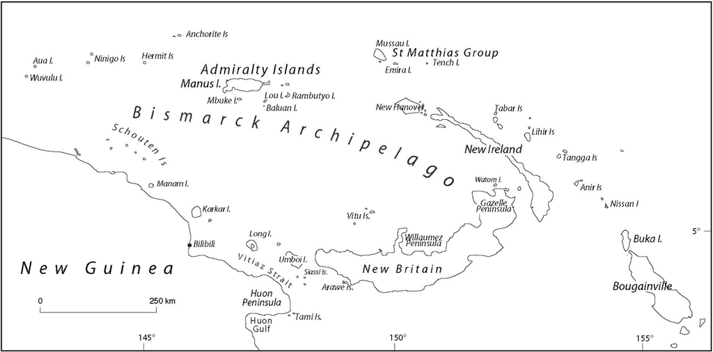

**Map 7:** The Bismarck Archipelago, Bougainville and the adjacent coast of New Guinea

Cyclones are common in the southeast Solomons and occur as far north as Bougainville. However, the Bismarck Archipelago lies in a sheltered band between N and S tropical cyclone belts (Irwin 1992). SE Trade winds blow consistently from May to September, but between December and March the more erratic NW Monsoon winds prevail.

The NW monsoons bring very high rainfall (up to six metres a year in some regions) in the months of the southern hemisphere summer. SE Trades bring drier weather in the winter months. Rain forests cover much of the land. On high islands altitude differences correlate with marked changes in the flora and in the character of the forest. The lowland forests typically contain large trees of 30–45 m in height, with large leaves and large buttresses, and there are many woody climbers. Higher up, trees are shorter, have smaller leaves, and trees carry mosses and ferns. There are strand forests, mangrove forests and man-made grasslands.

New Britain is the largest island in Melanesia other than New Guinea. Much of the shoreline is bounded by coral reefs. Along the coast there are a number of protected bays and harbours and beaches. Other parts of the shoreline are cliff-lined and still others are under mangrove swamps. Many more or less active volcanoes are present on the northern side of the island. Concomitant with these are crater lakes, beaches of black sand, hot springs and geysers. A rugged central mountain chain separates the north and south coasts, and much of the interior is uninhabited or thinly populated. The south coast differs in appearance and structure from the north, being composed predominantly of raised coral and other marine deposits of varying age, with narrow coastal plains or coraline cliffs that fall steeply into the sea. Because the central mountain range acts as a barrier to the NW Monsoon winds, creating a rain shadow, the leeward south coast of New Britain gets less than half the rainfall of windward north coast.

Numerous small islands lie immediately offshore from New Britain. More distant are the larger, densely forested, volcanic islands of the Vitu group, Garove and Unea, which are visible from the Willaumez Peninsula.

New Ireland with New Hanover as its northern extension is a little over 350 km long, but never more than 50 km across. It has a mountainous spine that broadens out in the south to a plateau rising to 2400 metres. On the west side mountains rise steeply from the coast and there is little flat land. A coastal plain is more in evidence along the east coast, with mountains rising fairly sharply at its western limit. There are limited stretches of reef along the east coast. Four substantial island groups, Tabar, Lihir, Tangga and Anir (formerly Feni), lie in a chain to the east of New Ireland. All four are volcanic, with some fringing reef.

The Mussau or St Matthias group is located about 100 km north of New Ireland and 230 km east of Manus. The largest island of the group, Mussau, has a volcanic core remnant rising to 650 m. There are eleven small upraised coral islands clustered south of the main island. Eloaua and Emananus together form the east and west sides of an atoll with extensive fringing and barrier reefs which enclose a lagoon.

The Admiralty group consists of one large island, Manus, ringed by many small islands. Manus is 100 km long by 30 km wide, with mountainous terrain, dissected by many streams which have cut deep valleys. The island is covered by rainforest of the lowland type and by sago and mangrove swamps. Soil fertility is generally poor. Heavy rainfail has washed away the topsoil and this factor and the broken nature of the land renders most of the island unsuitable for agriculture. Situated just off the north coast of Manus are a number of small coral atolls and sand cays whose inhabitants live mainly by fishing and trading in foodstuffs, their environment providing only limited opportunities for cultivating crops. To the south and east of Manus, and further offshore than the coral atolls are a number of high islands of volcanic origin, including Lou, Rambutjo, Baluan and M’Buke, whose soils are fertile and intensively cultivated. Far to the west of Manus lie several clusters of atolls: the Hermit group, the Anchorites (Kaniet) and west of these, the Ninigo group. Still further west are the atolls of Wuvulu and Aua.

The reader is referred to subsequent chapters to see how consistent the reconstructed Proto Oceanic lexicon for the geophysical environment is with the assumption that the speech community was located in the Bismarck Archipelago. Most of the relevant lexical reconstructions will be found in Chapters 3–5, dealing with landscape, seascape and meteorology. As few if any of the reconstructed geomorphological and meteorological referents are unique to the Bismarcks, it is unlikely that the lexical reconstructions will identify the Bismarcks as the only possible location of Proto Oceanic. However, it is of interest to see whether the reconstructions include any referents that are missing from the Bismarcks, or whether they fail to include names for some salient items that are present there.

## Notes

[^1]: I am indebted to Roger Green, Meredith Osmond, Malcolm Ross and Christophe Sand for helpful comments on a draft of this chapter. A number of issues to do with locating Proto Oceanic are raised in a paper by Terrell, Hunt and Bradshaw (2002) which came to hand after this paper was written.
[^2]: See Green (1991b) for an extended discussion of the Near Oceania vs Remote Oceania division, first proposed in Pawley and Green (1973).
[^3]: There are several recent major syntheses of interdisciplinary evidence concerning the Austronesian diaspora by archaeologists, especially Bellwood (1997), Green (2003), Kirch (1995, 1997, 2000), Kirch and Green (2001) and Spriggs (1997a), with a dissenting view presented by Terrell (1986) and Terrell et al. (2001). For overviews by linguists see Blust (1995b), Pawley (2003a) and Pawley and Ross (1993, 1995).
[^4]: At least two and probably three other movements into Remote Oceania occurred at about the same time as the Lapita expansion, but independently of it. All were into western Micronesia and all can be associated with Austronesian languages. The Mariana Islands, forming the northwest margin of Micronesia, were settled by at least the late 2nd millennium BC (Bonhomme & Craig 1987). Belau (Palau), at the western margin of the Carolines, was perhaps settled about the same time although as yet there are no published dates earlier than 600 BC. The sources of these movements were probably the Philippines and/or Sulawesi. Early assemblages in the Marianas and Belau show a red slip decorated earthenware remarkably similar to that found in the southern Philippines and Sulawesi—and to the Lapita tradition. It is likely that Yap (Western Carolines) was also settled very early. The highly divergent Yapese language is Oceanic but cannot on present evidence be subgrouped with any other member of Oceanic (Ross 1996a).
[^5]: Some archaeologists have in the past favoured a predominantly local origin of Lapita in the Bismarck archipelago (Allen 1984, Allen & Gosden 1996, Allen & White 1989, Gosden & Specht 1991, Terrell 1986, Terrell & Welsch 1997, Terrell, Kelly & Rainbird 2001, White 1996). They point out that the Bismarck archipelago had a long history of human occupation before the appearance of Lapita and that there are precedents for some elements of Lapita technology and trade patterns in the pre-Lapita period there, including lagoon fishing, trochus shell armrings, one piece shell fishhooks, earth ovens, and trade in obsidian.
[^6]: Some archaeologists have in the past favoured a predominantly local origin of Lapita in the Bismarck archipelago (Allen 1984, Allen & Gosden 1996, Allen & White 1989, Gosden & Specht 1991, Terrell 1986, Terrell & Welsch 1997, Terrell, Kelly & Rainbird 2001, White 1996). They point out that the Bismarck archipelago had a long history of human occupation before the appearance of Lapita and that there are precedents for some elements of Lapita technology and trade patterns in the pre-Lapita period there, including lagoon fishing, trochus shell armrings, one piece shell fishhooks, earth ovens, and trade in obsidian.
[^7]: See Blust (1995b), Kirch (2000), Kirch and Green (2001), Pawley and Green (1984), Pawley and Ross (1994), and Ross, Pawley and Osmond (1998) for overviews and extensive references in this field.
[^8]: Some archaeologists and molecular biologists tend to talk of Austronesian speakers, rather than Oceanic speakers, settling Melanesia and Polynesia. This is correct but unnecessarily vague. It is rather like talking about the Celtic or the Anglo-Saxon colonisations of Britain as being carried out by speakers of Indo-European languages.
[^9]: George Grace argued some 40 years ago (Grace 1961, 1964) that the immediate ancestor of the Oceanic languages was probably spoken within a zone bounded by the north coast of New Guinea in the south and the Bismarck Archipelago in the north. At that time his chief grounds were then current ideas about the genetic classification of the Austronesian languages and what was known of the prehistory of Southeast Asia and the Pacific. Since Grace’s initial proposal our understanding of the subgrouping of the Austronesian family as a whole and of the Oceanic branch has advanced a good deal. These advances have broadly supported and strengthened his hypothesis. Some years later, I suggested (Pawley 1981) that in its final stage Proto Oceanic consisted of an extensive dialect chain, probably extending from New Britain and New Ireland to San Cristobal in the eastern Solomons. The arguments were based on several factors: (i) the geographic distribution of subgroups, which showed many (apparent) primary subgroups scattered across Melanesia, (ii) assumptions about the settlement patterns, social organisation and behaviour of early Oceanic speakers (settling mainly on coasts and small islands, with kingroups dispersing but remaining in contact for some generations, (iii) assumptions about the voyaging technology and capabilities and (iv) archaeological dating of the spread of the Lapita culture, indicating that this culture was carried rapidly across Melanesia in the 2nd millennium BC. That paper may have overestimated the extent of the dialect chain, but it did bring up the question: If there was an extensive dialect chain, how can we decide at what point Proto Oceanic broke up? Malcolm Ross (1988) proposed a more specific dispersal centre for Proto Oceanic, namely the region east of the Talasea Peninsula on the north coast of New Britain. This now appears too specific. It might be proposed that this region has stronger claims to be the homeland of the Western Oceanic subgroup before its dispersal over New Britain, New Ireland, the western Solomons and the New Guinea mainland. However, I believe that such a proposal would be open to the same objection as the previous one. Ross holds that Proto Western Oceanic was not a well-defined subgroup but a dialect chain, specifically that part of the Proto Oceanic dialect chain that was left in the New Britain-New Ireland region when Oceanic speakers moved out of the Bismarcks and into Remote Oceania. But if Proto Oceanic speakers were already widely dispersed across the New Britain-New Ireland region at this point, as I have argued, then the later Western Oceanic dialect chain would also have extended over this region.
[^10]: See Ross (1988:21) for some traces of ancient loans from a Pre-Oceanic source in Papuan languages of Madang Province.